# Overview of Explanatory Variables

Analyzing and visualizing KSU explanatory variables

Kelli Feeser

2023-10-02

[Back to Home](https://kellifeeser.github.io/ksu-paired-amplicon-workflow/index.html)

```r
opts <- options(knitr.kable.NA = "")
```

# 1 Metadata structure

## 1.1 Sampling Variables

*Categorical*

- **Site**
  - n = 23
- **Grassland type**
  - n = 4
  - tallgrass, mixed grass, shortgrass, desert
- **Grass host species**
  - n = 5
    - ANGE (*Andropogon gerardii* / Big bluestem)
    - SCSC (*Schizachyrium scoparium* / Little bluestem)
    - BOER (*B. eriopoda* / Black grama)
    - BOGR (*B. gracilis* / Blue grama)
    - BUDA (*Bouteloua dactyloides* / Buffalograss)
- **Latitudinal Bin**
  - n = 4
  - North, North Central, South Central, South
- **Longitudinal Gradient**:
  - n = 3
  - East, Middle, West

*Continuous*

- **Elevation** (in meters)
  - ranges from -20 to 2,747 m
- **Latitude**
  - 29.23005 to 41.12200° N
- **Longitude**
  - -108.28760 to -94.13184° W

## 1.2 Climate Data

*Continuous*

- **GDD** = growing degree days (determined over 3- and 30-year windows and 2015)
- **ppt** = mean annual precipitation (determined over 3- and 30-year windows and 2015)

## 1.3 Edaphic Variables

*Continuous*

- **soil_moisture**
- **ammonium**
- **nitrate**
- **phosphorous**
- **SOM** (via LoI)
- **pH**

## 1.4 Plant Traits

*Continuous*

# 2 Data Standardization/Transformations

All continuous data (climate, edaphic, and plant trait) were mean standardized. All predictors were scaled to mean = 0 and SD = 1.

## 2.1 Collinearity

I assessed multicollinearity and removed correlated predictors, retaining ammonium over nitrate and soil moisture over similar measurements. For climate, only retaining 3yr values.

### Climate

Retaining GDD3yr over GDD2015 (degree growing days) & similarly, ppt3yr (mean annual precipitation)

### Edaphic

Retaining soil_moisture over GWC and percent soil moisture (complement). Retaining ammonium over nitrate because Rudgers2021 did. I am considering removing phos.

### Plant Trait

n/a

### Mixed

Precipitation is highly correlated to longitude. Interesting…

# 3 Summary by variable

For these variable summaries, I am showing *non-standardized*/raw data values.

```r
# Load required libraries
library(ggplot2)
library(dplyr)
library(tidyr)
library(corrplot)

# Define the list of explanatory variable names
#var_all <- c("var1", "var2", "var3")  # Add all variable names here

# Define the dataframe containing the data
Bac_all_meta_df1 <- data.frame(sample_data(Bac_m.std))

idx <- match(var_all_ut, names(Bac_all_meta_df1))
idx <- sort(c(idx))

Bac_all_meta_df <- Bac_all_meta_df1[,idx]
Bac_all_meta_dfN <- select_if(Bac_all_meta_df, is.numeric)

# Loop through each explanatory variable
for (var in var_all_numeric_ut) {

  # Print the current variable being explored
  cat("## ", var, " {.unnumbered} \n\n")

  # Summary statistics
  summary_stats <- summary(Bac_all_meta_dfN[[var]])
  cat("Summary Statistics:\n")
  print(summary_stats)
  cat("\n")

  # Histogram
  hist_plot <- ggplot(Bac_all_meta_dfN, aes(x = !!sym(var))) +
    geom_histogram(fill = "skyblue", color = "black", bins = 20) +
    labs(title = paste("Histogram of", var),
         x = var, y = "Frequency") +
    theme_minimal()

  # Save histogram plot
  hist_file <- paste0("../figures/explanatory_variables/histogram_", var, ".png")
  ggsave(hist_file, hist_plot, width = 6, height = 4)

  # Print histogram plot
  cat("Histogram Plot:\n")
  # knitr::include_graphics(hist_file)
  cat("![](../figures/explanatory_variables/histogram_",var,".png)", sep = "")
  cat("\n\n")

  # Check variance
  # cat("Variance:\n")
  # var_val <- var(Bac_all_meta_df[[var]])
  # cat("Variance of", var, ":", var_val, "\n\n")

  # Check variations by "Site" variable
  # cat("Variations in ", var, "by Site, Latitudinal Bin, Longitudinal Gradient, Grass Host:\n")
  # site_variations <- Bac_all_meta_df %>%
  #   group_by(Site) %>%
  #   summarise(mean_val = mean(!!sym(var), na.rm = TRUE),
  #             sd_val = sd(!!sym(var), na.rm = TRUE))
  #
  # print(site_variations)
  # cat("\n\n")
}
```

## Latitude

Summary Statistics: Min. 1st Qu. Median Mean 3rd Qu. Max. 29.23 31.96 36.02 35.37 39.07 41.12

Histogram Plot:

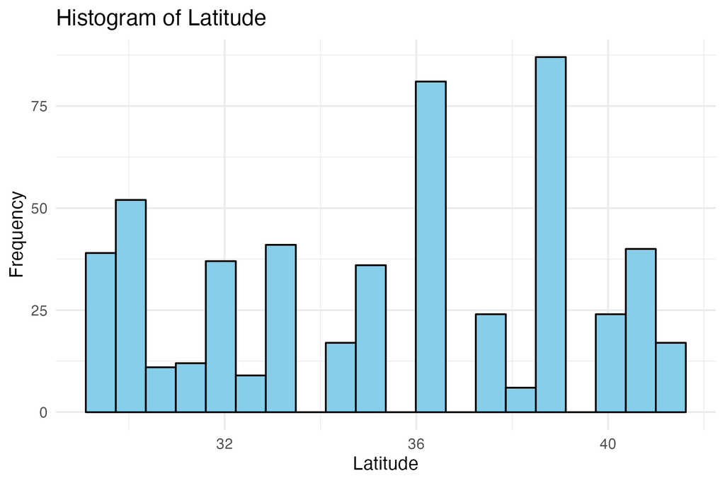

## Longitude

Summary Statistics: Min. 1st Qu. Median Mean 3rd Qu. Max. -108.29 -104.53 -98.91 -100.27 -97.52 -94.13

Histogram Plot:

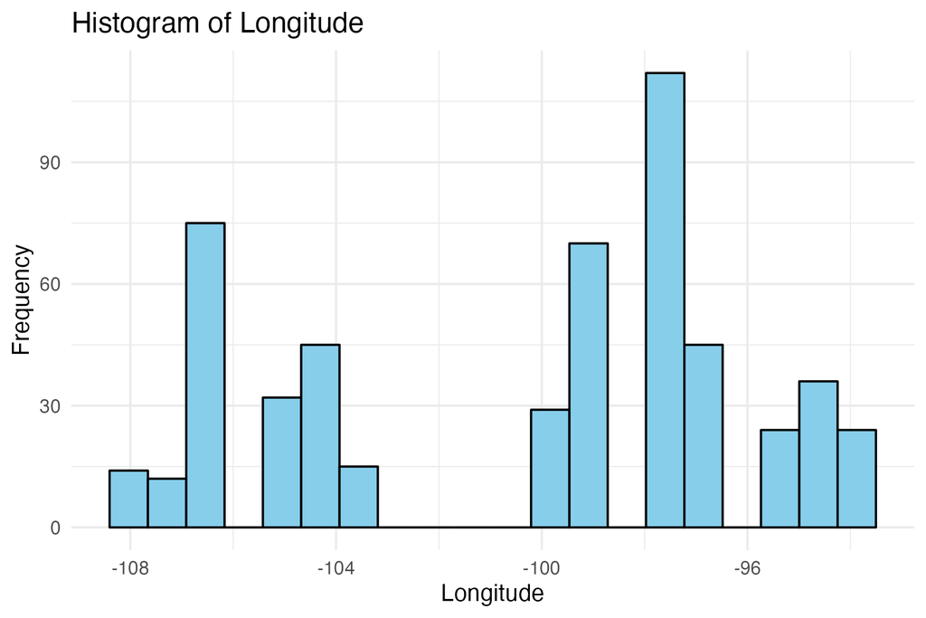

## Elevation_m

Summary Statistics: Min. 1st Qu. Median Mean 3rd Qu. Max. -19.8 335.0 635.0 916.4 1551.0 2747.0

Histogram Plot:

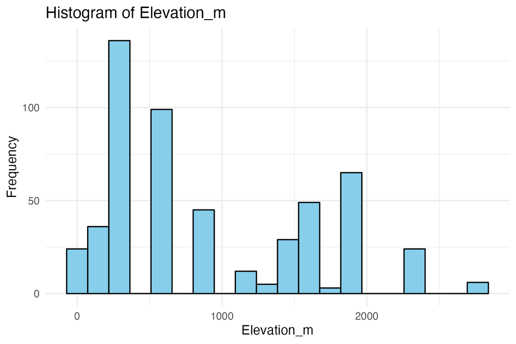

## GDD3yr

Summary Statistics: Min. 1st Qu. Median Mean 3rd Qu. Max. 2048 3935 4427 4480 5010 6005

Histogram Plot:

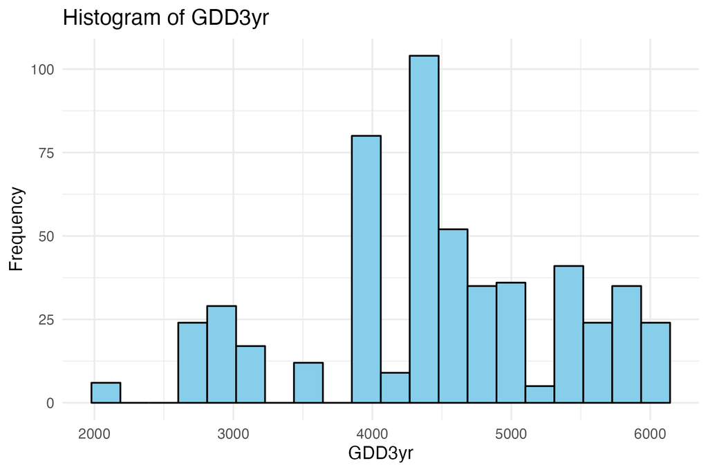

## ppt3yr

Summary Statistics: Min. 1st Qu. Median Mean 3rd Qu. Max. 188.4 415.2 606.2 617.2 858.3 1064.2

Histogram Plot:

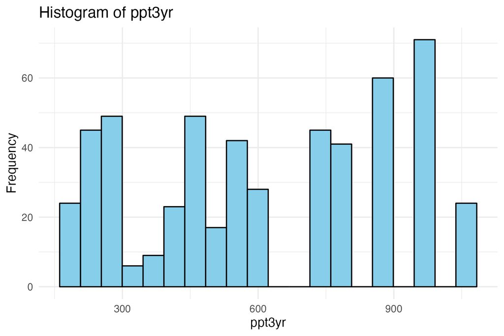

## avg_SRL

Summary Statistics: Min. 1st Qu. Median Mean 3rd Qu. Max. 659.4 1523.6 1732.1 1858.3 2150.4 3306.4

Histogram Plot:

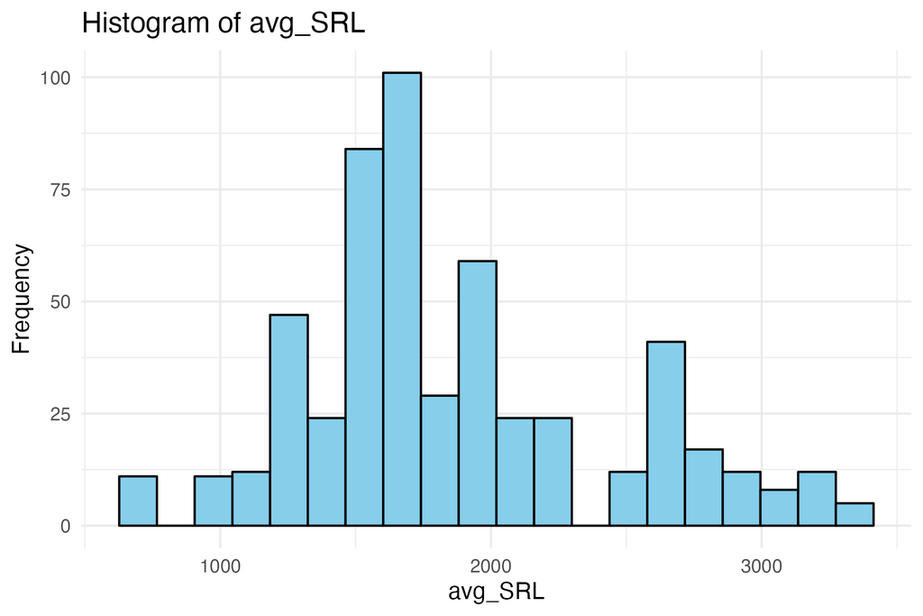

## soil_moisture

Summary Statistics: Min. 1st Qu. Median Mean 3rd Qu. Max. 0.6474 0.8291 0.8780 0.8713 0.9333 0.9889

Histogram Plot:

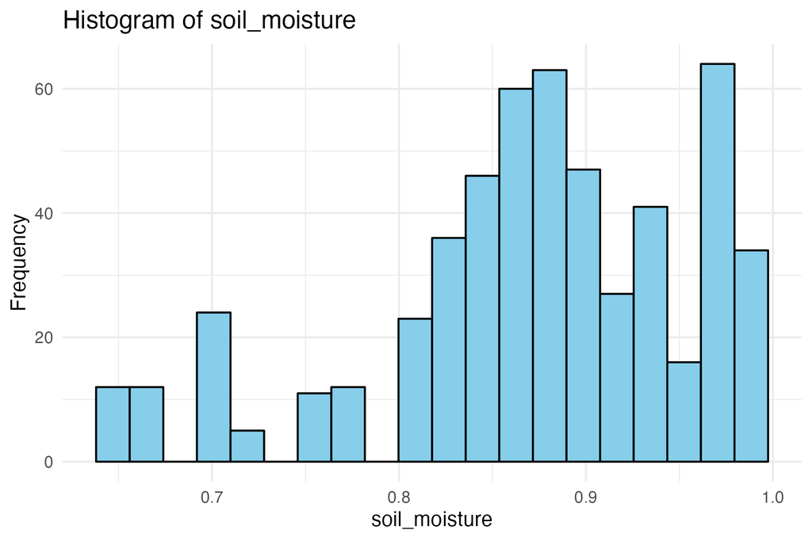

## pH

Summary Statistics: Min. 1st Qu. Median Mean 3rd Qu. Max. 5.050 6.670 7.250 7.109 7.750 8.360

Histogram Plot:

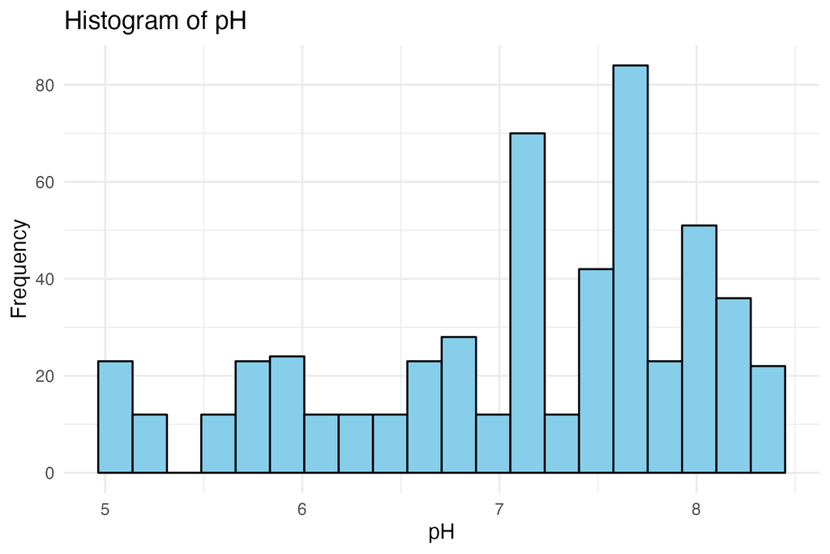

## phos

Summary Statistics: Min. 1st Qu. Median Mean 3rd Qu. Max. 0.1705 0.1828 0.1937 0.1975 0.2041 0.2690

Histogram Plot:

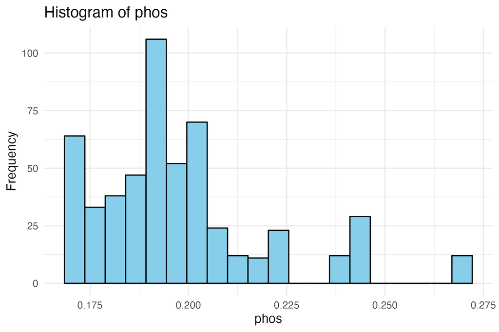

## ammonium

Summary Statistics: Min. 1st Qu. Median Mean 3rd Qu. Max. 0.8722 0.9233 0.9976 1.0100 1.0470 1.3796

Histogram Plot:

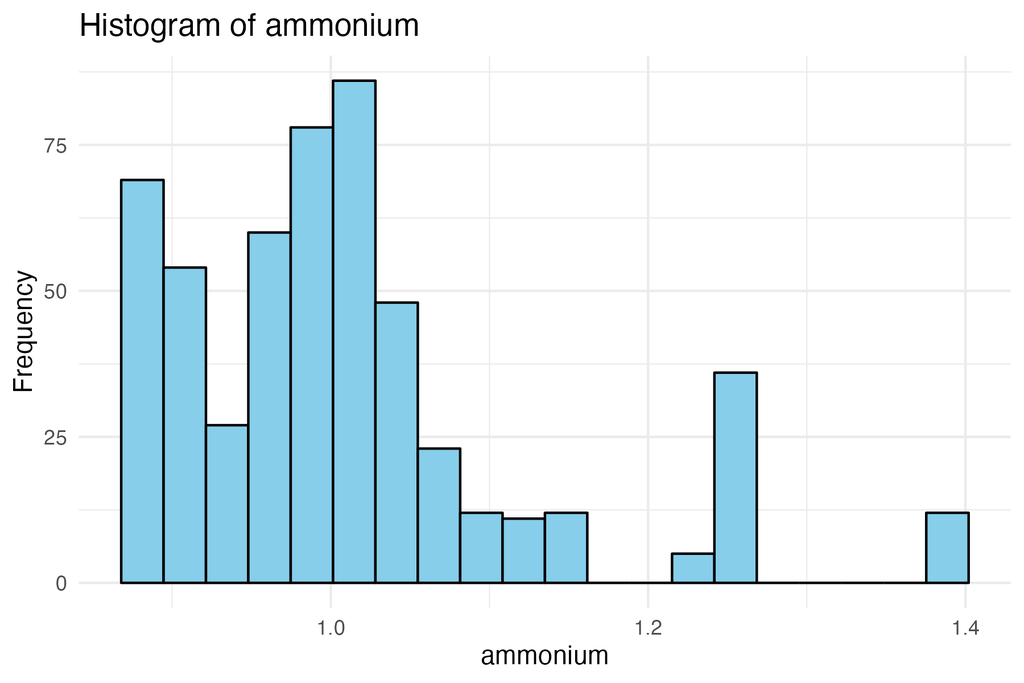

## SOM

Summary Statistics: Min. 1st Qu. Median Mean 3rd Qu. Max. 0.4508 2.0087 4.3897 4.4058 6.8384 11.1393

Histogram Plot:

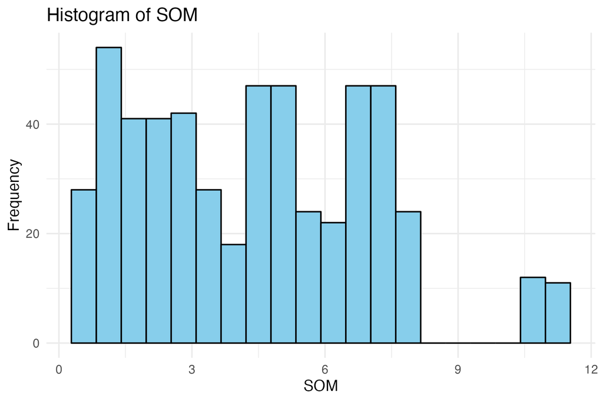

## avg_SLA

Summary Statistics: Min. 1st Qu. Median Mean 3rd Qu. Max. 98.42 124.81 139.78 141.27 155.90 191.04

Histogram Plot:

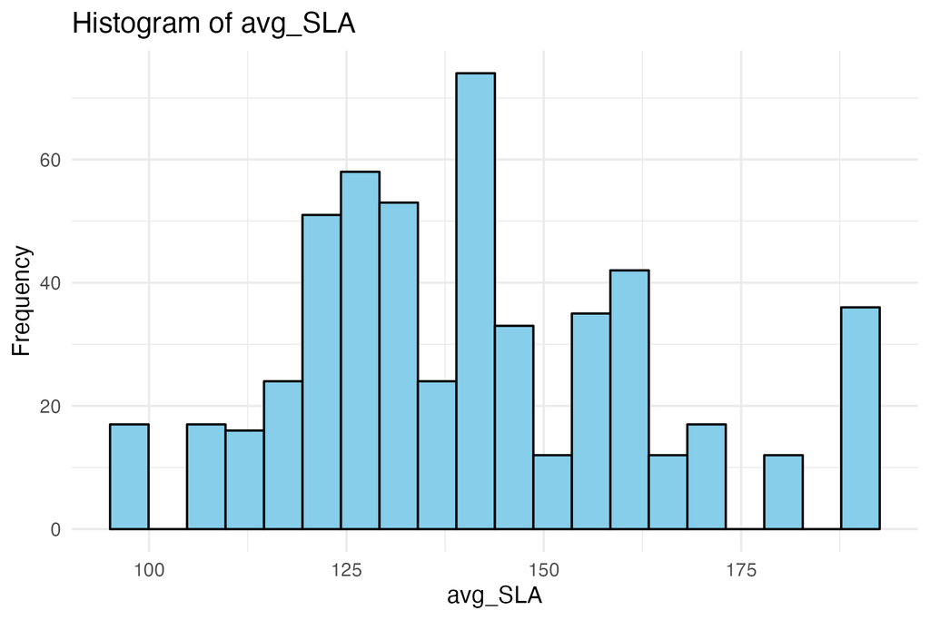

## herbivory_perc

Summary Statistics: Min. 1st Qu. Median Mean 3rd Qu. Max. 0.000 0.625 2.625 3.428 4.375 17.000

Histogram Plot:

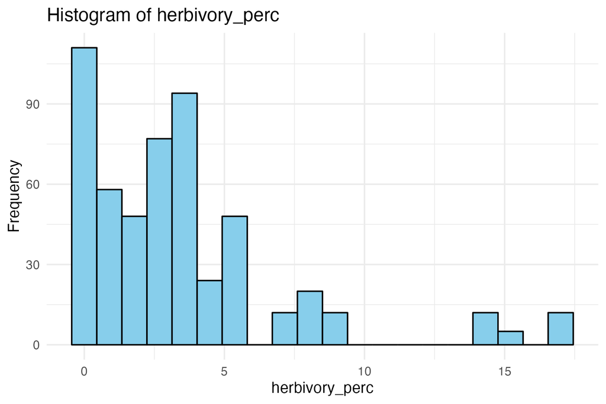

```r
# summary(aov(soil_moisture ~ Site, data = Bac_all_meta_df))
#
# m1<-(aov(soil_moisture ~ Grass*Site+Bin+Gradient, data = Bac_all_meta_df))
# m2<-(aov(soil_moisture ~ Grass+Bin+Gradient, data = Bac_all_meta_df))
#
# # fit the regression model
# model_sampling <- lm(soil_moisture ~ Grass+Bin+Gradient+Elevation_m+Grassland, data = Bac_all_meta_df)
# model_climate <- lm(soil_moisture ~ GDD3yr+ppt3yr, data = Bac_all_meta_df)
# model_edaphic <- lm(soil_moisture ~ soil_moisture+pH+phos+ammonium+SOM, data = Bac_all_meta_df)
# model_plant <- lm(soil_moisture ~ avg_SRL+avg_SLA+herbivory_perc, data = Bac_all_meta_df)
#
#
# # get the F statistics and performance metrics
# summary(model)$fstatistic[1]
# 89.51454
#
# summary(model)$r.squared
# 0.6063617
#
# summary(model)$adj.r.squared
# 0.5995878
#
# # load package
# library(car)
#
# # calculate VIF for each predictor variable from fitted model
# vif(model,type="predictor")
```